```python
import matplotlib as plt
import pandas as pd
import numpy as np
```

# Introduction

## Pyplot tutorial

An introduction to the pyplot interface.

matplotlib.pyplot is a collection of command style functions that make matplotlib work like MATLAB. Each pyplot function makes some change to a figure: e.g., creates a figure, creates a plotting area in a figure, plots some lines in a plotting area, decorates the plot with labels, etc.

In matplotlib.pyplot various states are preserved across function calls, so that it keeps track of things like the current figure and plotting area, and the plotting functions are directed to the current axes (please note that "axes" here and in most places in the documentation refers to the axes part of a figure and not the strict mathematical term for more than one axis).

```python
import matplotlib.pyplot as plt
plt.plot([1, 2, 3, 4])
plt.ylabel('some numbers')
plt.show()
```

[output not shown]

If you provide a single list or array to the plot() command, matplotlib assumes it is a sequence of y values, and automatically generates the x values for you. Since python ranges start with 0, the default x vector has the same length as y but starts with 0. Hence the x data are [0,1,2,3].

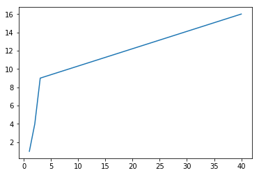

```python
plt.plot([1, 2, 3, 40], [1, 4, 9, 16])
```

```python
## Formatting the style
```

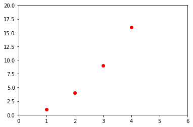

```python
plt.plot([1, 2, 3, 4], [1, 4, 9, 16], 'ro')  ### gx stands for green and x s the point. Replace with ro
plt.axis([0, 6, 0, 20])   ## take the min and max axis for x and y axis
plt.show()
```

#### plotting several lines with different format styles in one command using arrays.

```python
import numpy as np

# evenly sampled time at 200ms intervals
t = np.arange(0., 5., 0.2)   ## give interval as 0.2 and 0.5
```

```python
t
```

```
array([0. , 0.2, 0.4, 0.6, 0.8, 1. , 1.2, 1.4, 1.6, 1.8, 2. , 2.2, 2.4,
       2.6, 2.8, 3. , 3.2, 3.4, 3.6, 3.8, 4. , 4.2, 4.4, 4.6, 4.8])
```

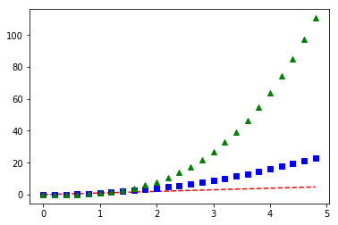

```python
# red dashes, blue squares and green triangles
plt.plot(t, t, 'r--', t, t**2, 'bs', t, t**3, 'g^')
plt.show()
```

```python
### Label x and Y axis
```

```
Text(0,0.5,'Y Value')
```

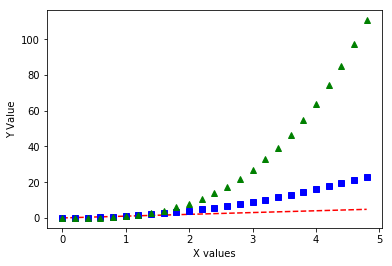

```python
 import numpy as np

# evenly sampled time at 200ms intervals
t = np.arange(0., 5., 0.2)   ## give interval as 0.2 and 0.5

plt.plot(t, t, 'r--', t, t**2, 'bs', t, t**3, 'g^')
plt.xlabel ('X values')
plt.ylabel("Y Value")
```

## Plotting Scatter diagram with multiple values

```python
data = {'a': np.arange(50),
        'c': np.random.randint(0, 50, 50),
        'd': np.random.randn(50)}
data['b'] = data['a'] + 10 * np.random.randn(50)
data['d'] = np.abs(data['d']) * 100
```

```python
data
```

```
{'a': array([ 0,  1,  2,  3,  4,  5,  6,  7,  8,  9, 10, 11, 12, 13, 14, 15, 16,
        17, 18, 19, 20, 21, 22, 23, 24, 25, 26, 27, 28, 29, 30, 31, 32, 33,
        34, 35, 36, 37, 38, 39, 40, 41, 42, 43, 44, 45, 46, 47, 48, 49]),
 'b': array([-12.69191199,  -1.89416383,  -4.96166962,  -0.29607426,
         10.04734471,  11.77944465,   1.74300306,  13.53820995,
          6.53576229,  -2.78865727,  -7.9889478 ,  15.07439999,
          9.95048014,   9.02847533,   5.84683829,  18.58742822,
         28.74540489,  22.85123431,   8.67715272,   9.24899416,
         31.93929643,   5.09742641,  32.33876252,  36.90566207,
         30.39607101,  20.01629965,  28.5387901 ,  32.72584539,
         48.33588138,  39.08803568,  34.29403383,  24.91664189,
         41.06087221,  24.49494688,  17.17224716,  29.78007072,
         23.29456782,  32.8281186 ,  25.40667199,  18.61557651,
         56.80971411,  40.59415417,  30.17840893,  38.44834067,
         53.84448794,  47.68056842,  38.72292273,  64.76326946,
         52.98711659,  49.75537876]),
 'c': array([ 5, 27, 25, 16, 35, 20,  7, 19, 34,  4, 26, 49, 39,  0,  5, 30,  3,
        18, 10,  0, 38, 41,  6,  6, 26,  7, 23, 23, 44, 19, 22, 39, 39, 38,
        10, 26, 21, 14, 13, 28, 45, 35,  3, 20,  0, 25, 14,  2,  1, 44]),
 'd': array([ 68.40902429,  69.21462148,  59.54861997,  62.98828011,
        127.96710322,  54.87653924,  12.44273045,  67.63819537,
          2.77369226, 183.53141444,  39.90462338,  14.0624788 ,
         36.07988973, 102.27232347,  11.61621138,  49.9337642 ,
          3.98242403,  27.91794607,  29.06841016, 117.33918275,
          2.10139029,  20.92514664, 122.2704532 ,  31.08495991,
         92.04785525,  22.60492492,  92.93615103, 297.05814702,
         68.18710853, 242.61718221, 181.59732687,  45.58349963,
         43.35168527,  22.62170687, 113.49934466, 134.0540164 ,
         25.27095334,  83.3883349 , 152.28914608,  66.30815575,
         64.69300263,   5.27860326,  19.19577702,  63.59110668,
         46.93108472,   1.24609526,  24.21043734, 114.95227999,
          8.52101834, 111.35757703])}
```

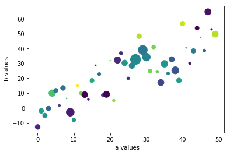

```python
plt.scatter('a', 'b', c='c', s='d', data=data) ### scatter plot
plt.xlabel(' a values')
plt.ylabel(' b values')
plt.show()
```

### Bar Charts with categorical values

```
<Container object of 3 artists>
```

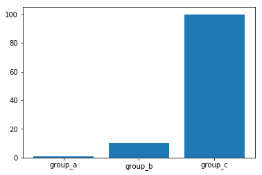

```python
names = ['group_a', 'group_b', 'group_c']
values = [1, 10, 100]

#plt.figure(1, figsize=(9, 3))

#plt.subplot(131)
plt.bar(names, values)
```

## Histogram

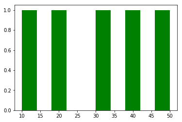

```python
x=[10,20,30,40,50]
# the histogram of the data
n, bins, patches = plt.hist(x, 10, facecolor='g')
```

### Subplotting

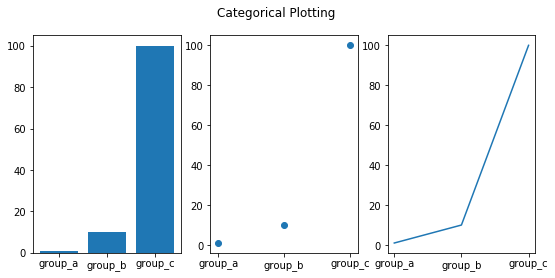

```python
names = ['group_a', 'group_b', 'group_c']
values = [1, 10, 100]

plt.figure(1, figsize=(9, 3))

plt.subplot(131)
plt.bar(names, values)
plt.subplot(132)
plt.scatter(names, values)
plt.subplot(133)
plt.plot(names, values)
plt.suptitle('Categorical Plotting')
plt.show()
```

## Controlling line properties

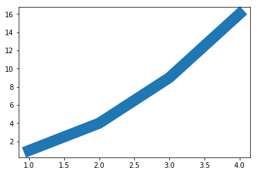

```python
x=[1,2,3,4]
y=[1,4,9,16]
plt.plot(x, y, linewidth=16.0)
```

## Working with multiple figures and axes

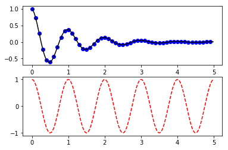

```python
 def f(t):
    return np.exp(-t) * np.cos(2*np.pi*t)

t1 = np.arange(0.0, 5.0, 0.1)
t2 = np.arange(0.0, 5.0, 0.02)

plt.figure(1)
plt.subplot(211)
plt.plot(t1, f(t1), 'bo', t2, f(t2), 'k')

plt.subplot(212)
plt.plot(t2, np.cos(2*np.pi*t2), 'r--')
plt.show()
```

The figure() command above is optional because figure(1) will be created by default, just as a subplot(111) will be created by default if you don't manually specify any axes.

The subplot() command specifies numrows, numcols, plot_number where plot_number ranges from 1 to numrows*numcols. The commas in the subplot command are optional if numrows*numcols<10. So subplot(211) is identical to subplot(2, 1, 1).

You can create an arbitrary number of subplots and axes. If you want to place an axes manually, i.e., not on a rectangular grid, use the axes() command, which allows you to specify the location as axes([left, bottom, width, height]) where all values are in fractional (0 to 1) coordinates. See Axes Demo for an example of placing axes manually and Basic Subplot Demo for an example with lots of subplots.

You can create multiple figures by using multiple figure() calls with an increasing figure number. Of course, each figure can contain as many axes and subplots as your heart desires:

```
Text(0.5,1,'Sample diagrams')
```

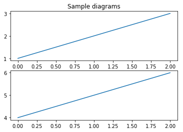

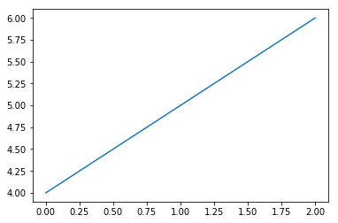

```python
import matplotlib.pyplot as plt
plt.figure(1)                # the first figure
plt.subplot(211)             # the first subplot in the first figure
plt.plot([1, 2, 3])
plt.subplot(212)             # the second subplot in the first figure
plt.plot([4, 5, 6])


plt.figure(2)                # a second figure
plt.plot([4, 5, 6])          # creates a subplot(111) by default

plt.figure(1)                # figure 1 current; subplot(212) still current
plt.subplot(211)             # make subplot(211) in figure1 current
plt.title('Sample diagrams') # subplot 211 title
```

## Working with text

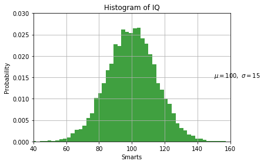

```python
mu, sigma = 100, 15
x = mu + sigma * np.random.randn(10000)

# the histogram of the data
n, bins, patches = plt.hist(x, 50, density=1, facecolor='g', alpha=0.75)


plt.xlabel('Smarts')
plt.ylabel('Probability')
plt.title('Histogram of IQ')
plt.text(150, 0.015, r'$\mu=100,\ \sigma=15$')   ### Write the text at a location
plt.axis([40, 160, 0, 0.03])
plt.grid(True)
plt.show()
```

# Ploting with Data frames

## Scatter plots

```python
df = pd.DataFrame(np.random.rand(50, 4), columns=['a', 'b', 'c', 'd'])
```

```python
df.head()
```

|  | a | b | c | d |
| --- | --- | --- | --- | --- |
| 0 | 0.758432 | 0.750170 | 0.396792 | 0.194482 |
| 1 | 0.362340 | 0.961704 | 0.364694 | 0.042913 |
| 2 | 0.202265 | 0.526815 | 0.470481 | 0.170710 |
| 3 | 0.883749 | 0.999683 | 0.134398 | 0.882380 |
| 4 | 0.427408 | 0.650158 | 0.853698 | 0.382309 |

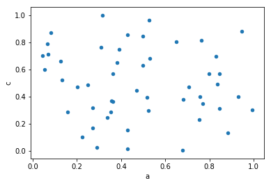

```python
df.plot.scatter(x='a', y='c');
```

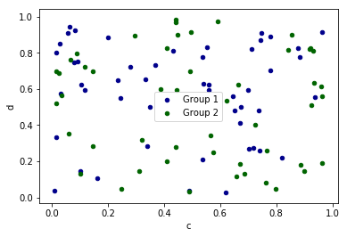

```python
ax = df.plot.scatter(x='a', y='b', color='DarkBlue', label='Group 1');
df.plot.scatter(x='c', y='d', color='DarkGreen', label='Group 2', ax=ax);
```

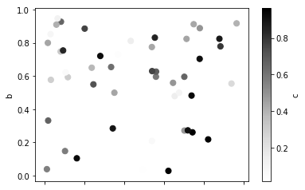

```python
df.plot.scatter(x='a', y='b', c='c', s=50);  ## The keyword c may be given as the name of a column to
#provide colors for each point:
```

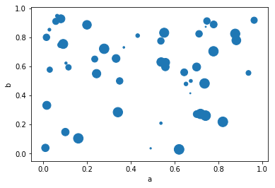

```python
df.plot.scatter(x='a', y='b', s=df['c']*200); ## You can pass other keywords supported by matplotlib scatter.
#The example below shows a bubble chart using a column of the DataFrame as the bubble size.
```

## Pie charts

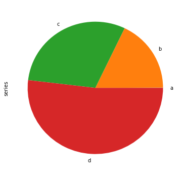

```python
series = pd.Series(3 * np.random.rand(4), index=['a', 'b', 'c', 'd'], name='series')

series.plot.pie(figsize=(6, 6))
```

```python
### Plotting with missing data
```

```python
#Plot Type	NaN Handling
#Line	Leave gaps at NaNs
#Line (stacked)	Fill 0’s
#Bar	Fill 0’s
#Scatter	Drop NaNs
#Histogram	Drop NaNs (column-wise)
#Box	Drop NaNs (column-wise)
#Area	Fill 0’s
#KDE	Drop NaNs (column-wise)
#Hexbin	Drop NaNs
#Pie	Fill 0’s
```

## Scatter Matrix Plot

```
array([[<matplotlib.axes._subplots.AxesSubplot object at 0x1184c75f8>,
      dtype=object)
```

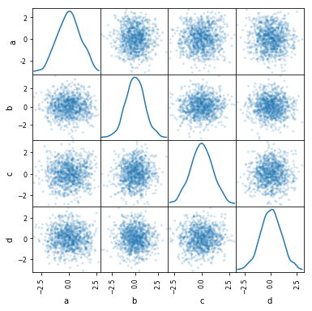

```python
from pandas.plotting import scatter_matrix
df = pd.DataFrame(np.random.randn(1000, 4), columns=['a', 'b', 'c', 'd'])
scatter_matrix(df, alpha=0.2, figsize=(6, 6), diagonal='kde')
```

```python
ser = pd.Series(np.random.randn(1000))
```

```python
ser
```

```
0     -1.446929
1      1.600351
2      1.934216
3      1.265296
4     -0.455647
5     -1.331358
6     -0.991572
7     -0.712201
8      1.660196
9      1.256821
10    -1.917565
11    -1.095573
12     0.873846
13    -0.751846
14    -0.493948
```

[output cut: 47 more lines]

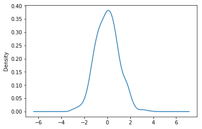

```python
ser.plot.kde()
```

```python
ts = pd.Series(np.random.randn(1000), index=pd.date_range('1/1/2000', periods=1000))
```

```python
ts.head()
```

```
2000-01-01   -0.428932
2000-01-02   -1.539724
2000-01-03    1.018285
2000-01-04    0.220492
2000-01-05    0.648084
Freq: D, dtype: float64
```

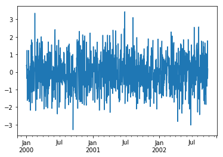

```python
ts.plot()
```

```python
ts=ts.cumsum()
```

```python
ts.head()
```

[output not shown]

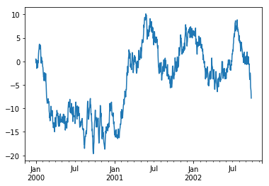

```python
ts.plot()
```

```python
df = pd.DataFrame(np.random.randn(1000, 4), index=ts.index, columns=list('ABCD'))
```

```python
df.head()
```

|  | A | B | C | D |
| --- | --- | --- | --- | --- |
| 2000-01-01 | -0.000782 | 0.413193 | -0.505423 | -1.619944 |
| 2000-01-02 | 0.088215 | -1.307892 | 0.825723 | -0.411888 |
| 2000-01-03 | -0.982500 | -1.231147 | 0.674062 | 0.638380 |
| 2000-01-04 | -0.939548 | 1.119926 | 0.207276 | 1.375120 |
| 2000-01-05 | -0.238893 | 1.466646 | 0.786750 | -0.190115 |

```python
df = df.cumsum()
```

```python
df.head()
```

|  | A | B | C | D |
| --- | --- | --- | --- | --- |
| 2000-01-01 | -0.000782 | 0.413193 | -0.505423 | -1.619944 |
| 2000-01-02 | 0.087433 | -0.894699 | 0.320300 | -2.031832 |
| 2000-01-03 | -0.895068 | -2.125846 | 0.994362 | -1.393453 |
| 2000-01-04 | -1.834615 | -1.005920 | 1.201638 | -0.018332 |
| 2000-01-05 | -2.073509 | 0.460726 | 1.988389 | -0.208448 |

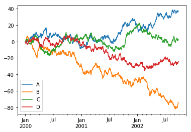

```python
plt.figure();
df.plot();
```

```python
####  Plot X vs Y
```

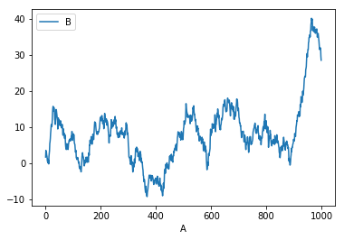

```python
df3 = pd.DataFrame(np.random.randn(1000, 2), columns=['B', 'C']).cumsum()
df3['A'] = pd.Series(list(range(len(df))))

df3.plot(x='A', y='B')
```

# Plotting styles

```python
#‘bar’ or ‘barh’ for bar plots
#‘hist’ for histogram
#‘box’ for boxplot
#‘kde’ or ‘density’ for density plots
#‘area’ for area plots
#‘scatter’ for scatter plots
#‘hexbin’ for hexagonal bin plots
#‘pie’ for pie plots
```

```python
## Bar plots
```

```python
#df
```

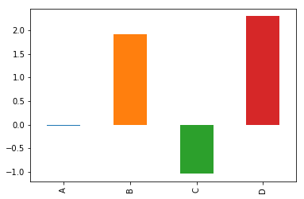

```python
df.iloc[5].plot(kind='bar')
```

```python
df2 = pd.DataFrame(np.random.rand(10, 4), columns=['a', 'b', 'c', 'd'])
```

```python
df2
```

[output not shown]

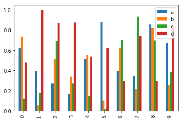

```python
df2.plot.bar()
```

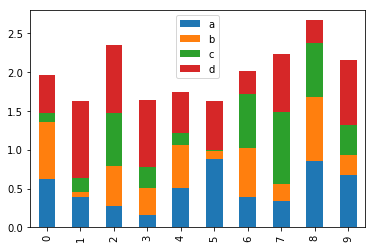

```python
df2.plot.bar(stacked=True)  ## Stacked bar plot
```

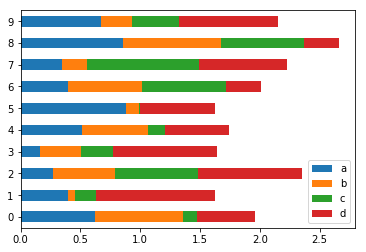

```python
df2.plot.barh(stacked=True);  ## barh for horizontal chart
```

## Histograms

```python
df4 = pd.DataFrame({'a': np.random.randn(1000) + 1, 'b': np.random.randn(1000),
   ....:                     'c': np.random.randn(1000) - 1}, columns=['a', 'b', 'c'])
   ....:
```

```python
df4.head()
```

|  | a | b | c |
| --- | --- | --- | --- |
| 0 | -0.982519 | 0.595909 | -0.560805 |
| 1 | 2.089860 | -0.323213 | -2.524127 |
| 2 | 1.614400 | -0.431324 | 0.049815 |
| 3 | 0.357787 | -2.033587 | -0.930862 |
| 4 | -0.564463 | -0.981110 | -2.421912 |

```python
df4.shape
```

```
(1000, 3)
```

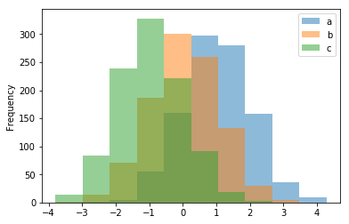

```python
df4.plot.hist(alpha=0.5)
```

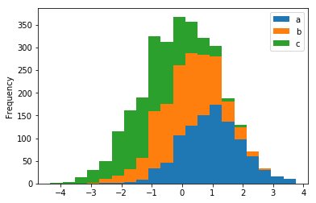

```python
plt.figure()

df4.plot.hist(stacked=True, bins=20)
```

## BOX PLOTS

```python
pd.DataFrame(np.random.rand(10, 5), columns=['A', 'B', 'C', 'D', 'E'])
```

|  | A | B | C | D | E |
| --- | --- | --- | --- | --- | --- |
| 0 | 0.985150 | 0.148687 | 0.328022 | 0.354276 | 0.406243 |
| 1 | 0.107348 | 0.592254 | 0.503392 | 0.263078 | 0.172611 |
| 2 | 0.900218 | 0.206362 | 0.344046 | 0.301627 | 0.698807 |
| 3 | 0.919302 | 0.675125 | 0.463337 | 0.540489 | 0.975243 |
| 4 | 0.747132 | 0.167922 | 0.188190 | 0.641458 | 0.300825 |
| 5 | 0.942161 | 0.490481 | 0.060652 | 0.568740 | 0.182944 |
| 6 | 0.946636 | 0.835830 | 0.252980 | 0.545416 | 0.479930 |
| 7 | 0.799311 | 0.985099 | 0.410661 | 0.529331 | 0.596889 |
| 8 | 0.338435 | 0.008464 | 0.221681 | 0.122404 | 0.855385 |
| 9 | 0.196104 | 0.926474 | 0.746771 | 0.580308 | 0.248596 |

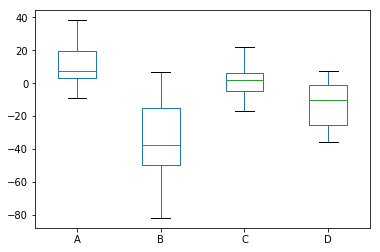

```python
df.plot.box()
```

[figure not shown]

Box plots are graphical tools to visualize key statistical measures, such as median, mean and quartiles.

A single box plot can be used to represent all the data. It is also possible to visualize separate statistics for subsets by selecting a column for the X-axis.

The individual box plot is a visual aid to examining key statistical properties of a variable. The diagram above shows how the shape of a box plot encodes these properties. The range of the vertical scale is from the minimum to the maximum value of the selected column, or, to the highest or lowest of the displayed reference points

# Plot Formatting

## 3 General Plot style arguements

[figure not shown]

```python
#plt.figure();
ts.plot(style='k--', label='Series');
```

### Controlling the Legend¶

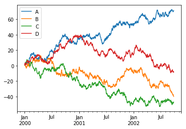

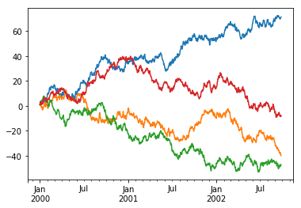

```python
df = pd.DataFrame(np.random.randn(1000, 4), index=ts.index, columns=list('ABCD'))

df = df.cumsum()

df.plot(legend=True)
df.plot(legend=False)  # Hides the legend
```

[figure not shown]

```python
df.plot(subplots=True, layout=(3, 3), figsize=(6, 6), sharex=False);  #change layout to 2,3 or 3,3
```

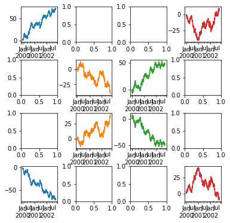

```python
import matplotlib as plt
### CHECK THIS  http://pandas.pydata.org/pandas-docs/stable/visualization.html?highlight=color
fig, axes = plt.pyplot.subplots(4, 4, figsize=(6, 6))

plt.pyplot.subplots_adjust(wspace=0.5, hspace=0.5);
target1 = [axes[0][0], axes[1][1], axes[2][2], axes[3][3]]

target2 = [axes[3][0], axes[2][1], axes[1][2], axes[0][3]]

df.plot(subplots=True, ax=target1, legend=False, sharex=False, sharey=False);
(-df).plot(subplots=True, ax=target2, legend=False, sharex=False, sharey=False);
```